# Milestone 04-05-2019

Seeam S. Noor

April 4, 2019

## Description of the Data

The Data has been taken from the [Kaggle profile of Zaeem Nalla](https://www.kaggle.com/zaeemnalla/premier-league#stats.csv). The creator of the dataset has made the data publicly available and ready for use in personal projects.

The data was acquired from the English Premier League Official website. It contains the match results of all football (also known as soccer) matches in the [English Premier League](https://www.premierleague.com/) seasons starting from 2006/2007 through 2017/2018.

Additionally, I will also do a mini data analysis on the Laliga (Spanish Football Leageue) as well. The data for that can be found [here](https://www.kaggle.com/spn007/la-liga-dataset#_=_).

There are three data sets.

1. Results.csv - Results of 4560 Premier League Matches. Dimensions of the data = 4561 X 6
2. Stats.csv - Basic statistics collected from Opta (official stats collector of the Premier League) of each team in every season (season totals) from 2006/2007 to 2017/2018. Dimensions of the data = 204 X 42
3. LaLiga_dataset.csv - Results of all matches of laliga from 1970/1971 to 2016/2017 season.  
   Dimensions of the data = 908 X 16

## Progress and Plans

Since I am from Bangladesh, the goal is to make the project something English Premier League Fans from Bangladesh would enjoy exploring.

So, at first I took a look at the data available and made a short list of what interesting analysis I could be doing. Then, I reached out to [Plaantik](http://plaantik.com/), a platform dedicated to football fans of Bangladesh with over [81,500 Facebook followers](https://www.facebook.com/plaantik/). Plaantik found the idea of a data analysis project to be interesting and made a public Facebook post asking its followers what type of analysis they would be interested in knowing. The response was overwhelming and it can be found [here](https://www.facebook.com/plaantik/posts/2370059273026323).

The Facebook post was a good way of gauging specific fan interest in analysis that they’d enjoy and provides a very good idea of where I can start.

## Interesting Plot

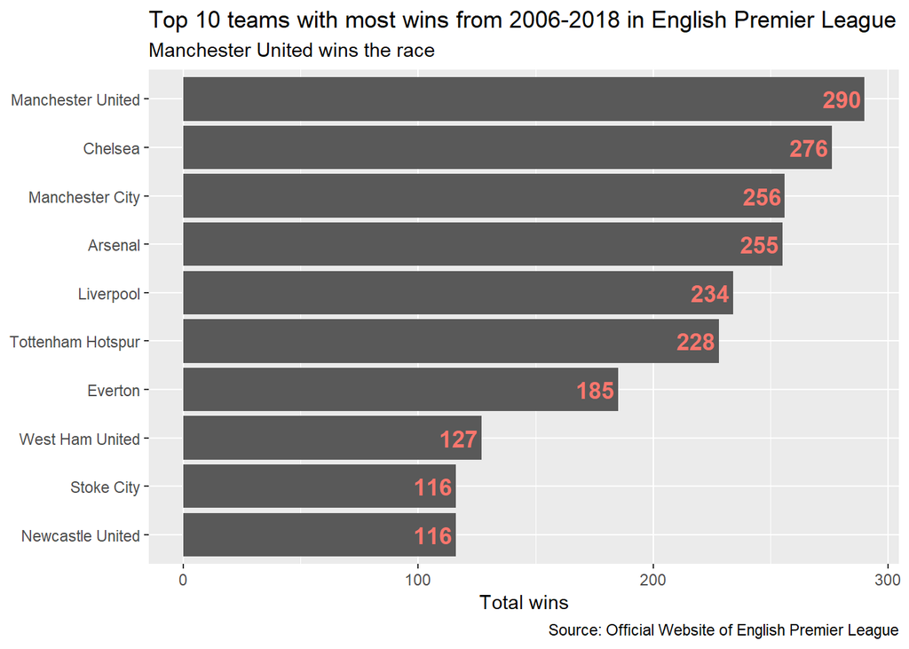